# Introduction

The modules that we are covering includes numpy, matplotlib and pandas.

```python
from matplotlib import pyplot as plt
import pandas as pd

# matplotlib customisation
plt.style.use('seaborn')
```

## Aim

To evaluate the significance of the differences between the one-tangent and two-tangent methods to find the decomposition potential.

# Theory behind Decomposition Potential

## What is decomposition potential?

Decomposition potential is the minimum potential required for continuous electrolysis (Blum and Vinal, 1934), it is also known as decomposition voltage. Decomposition potential does not have a well-defined value due to polarisation, and is obtained experimentally through approximation using graphical methods.

## Factors that affect decomposition potential

1. Nature of the electrolyte
2. Concentration of the electrolyte
3. Nature of the electrodes
4. Nature of the products of the electrolysis
5. Temperature
6. Polarisation

## Polarisation & Overvoltage

### Polarisation

All electrochemical reactions occur in a series of steps at the interface between electrode and electrolyte. Polarisation is the difference between the actual electrode potential where electrolysis begins and the standard reduction potential (E°), as it is based on environmental factors, determination of the value of polarisation is often not accurate. The difference is due to current flow or net charge flow (Stern and Geaby, 1957). There are three types of polarisation:

Activation Polarisation: This occurs due to resistance to electrochemical reaction kinetics that occur in the anode and cathode (Sadhukhan, 2017). One example is the accumulation of gases at the interface between the electrode and the electrolyte which results in an activation energy barrier associated with the slowest, rate-limiting step of an electrolytic process.

Concentration Polarisation: Occurs due to changes in concentration in the electrolyte solution at the interface between the electrode and the electrolyte (Perez, 2016), thus the reaction rate is limited by diffusion in the solution.

Ohmic/Resistance Polarisation: Occurs due to charge transport and the intrinsic electrical resistance in cell components like the electrodes and electrolyte. The electromotive force (e.m.f) decreases and the current increases, and vice versa, due to Ohm’s law (V = IR).

```
V is the voltage (V)
I is the current (A)
R is the resistance (Ω)
```

All cases lead to a decrease in the reduction potential of the electrodes (Kreka et al., 2018), a decrease in the rate of reaction (Yu, 2022) and the reaction eventually comes to a stop (Electrochemical Cells, 2021). Additionally, the applied electric current gets converted into heat instead of the desired electrochemical work (Thakre et al., 2019).

### Overvoltage

Also known as overpotential, overvoltage is needed in all electrolytic processes as it is the additional driving force required to overcome polarisation for the electrolytic process to proceed (Crow, 1974). Activation overvoltage, concentration overvoltage and ohmic overvoltage refer to the overvoltage required to overcome activation polarisation, concentration polarisation and ohmic polarisation respectively.

Overvoltage may be positive or negative. The sign is determined by the nature of the process: overpotentials for reduction are negative, since a more negative potential is more reducing. Conversely, overpotentials for oxidation are positive, since a more positive potential is more oxidizing (Stuve, 2014).

## Importance of decomposition potential

Scale-up factors for practical systems in high-power applications must take into account factors like current distribution across large-area electrodes, heat management and localized overcharge (Takeda et al., 2014). When the energy difference is bigger, the cost will be much more significant.

## Methods

### Theoretical Calculation

E° = -(ΔG°)/nF

```
  E° is the standard potential
  ΔG is the standard Gibbs free energy
  n is the number of electrons transferred in the reaction from the balanced reaction
  F is Faraday's constant (96 500 C/mol)
```

However, the theoretical calculation of decomposition potential is inaccurate as it does not account for resistance and concentration effects that require overvoltage for the reaction to take place (Electrolysis I, 2016). Thus, decomposition potential can only be approximated through experiments and the use of the graphical method.

### Graphical Method

[figure not shown]

Figure 1: Current-voltage curves obtained with a small cathode at 1298.15K

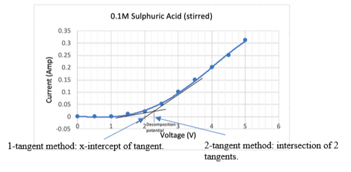

Figure 2: Comparison of the one-tangent and two-tangents method

To determine decomposition potential, a current-voltage curve is plotted. The value of the decomposition potential is obtained through the extrapolation of tangents at specific points.

As seen in Figure 1, the curve is sectioned into 4 points along the y-axis. The first and last sections are closely observed in all current-voltage curves, where the first branch of the curve is almost horizontal due to the applied voltage being below the deposition value of the cation. When the applied voltage at the electrode is above the deposition value of the cation, more current flows. This increases the value proportionately to the potential difference in excess of the deposition voltage (Cuthbertson and Waddington, 1936).

The last section of the curve is close to parallel to the y-axis, representing resistance. This indicates full conductivity of the electrolyte where both cations and anions are taking part in current conductivity (Cuthbertson and Waddington, 1936).

#### Two Tangent Method

The readings to generate the tangent are obtained below and above the decomposition potential. This is because, up to the decomposition potential the current flowing is either zero or very small despite the noticeable increase in voltage. Once the decomposition potential is exceeded, a sharp upturn in current for small increases in applied voltages is observed. Therefore, the voltage at which decomposition is set in must lie at the intersection of the two tangents (Maron and Prutton, 1965).

#### One Tangent Method

The second method only takes the tangent at the sharpest gradient and extrapolates it to find the x-intercept.

It was seen that the last branch of the curve is approximately parallel to the line. The value obtained by producing this part of the curve backwards to cut the x-axis is the decomposition potential, and should theoretically be equal to the corrected voltage corresponding to the last break in the curve (Cuthbertson and Waddington, 1936).

## What are we exploring?

The significance of the differences in decomposition potential values obtained when using the one-tangent and two-tangent methods.

# Code & Discussion

## Concept

For readability of the code, the first non-zero gradient will be referred to as the flattest gradient.

### One Tangent Method

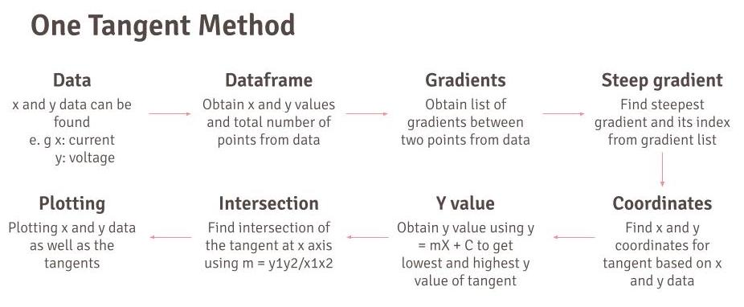

Figure 3: Flowchart on how the code for the one tangent method is developed

The intersection of the gradient for one tangent method can be calculated using:

m = $\dfrac{y_{2}-y_{1}}{x_{2}-x_{1}}$

Given the intersection coordinates is ($x_{2}$,0),

m = $\dfrac{0-y_{1}}{x_{2}-x_{1}}$

$\dfrac{-y_{1}}{m}$ = $x_{2}-x_{1}$

### Two Tangent Method

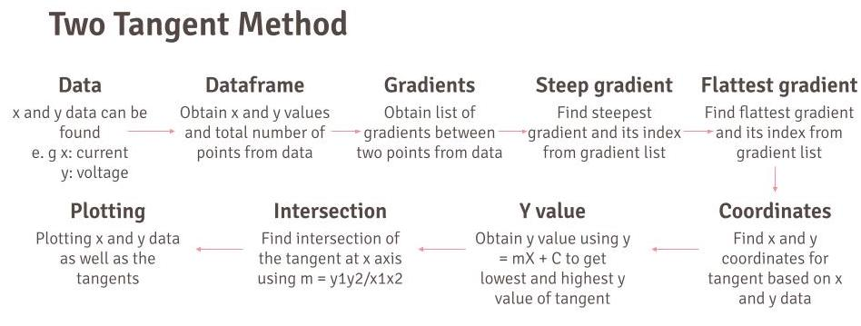

Figure 4: Flowchart on how the code for the two tangents method is developed

The intersection (x,y) is obtained by making use of the gradients of two tangents, the tangent with the steepest gradient and the tangent with the flattest gradient,

Given that $m_{1}$ at $(x_{1}, y_{1})$ is the steepest gradient, $m_{2}$ at $(x_{1}, y_{1})$ is the flattest gradient,

$m_{1}$ = $\dfrac{y_-y_{1}}{x-x_{2}}$ y = $m_{1}({x-x_{1}})+{y_{1}}$

$m_{2}$ = $\dfrac{y_-y_{2}}{x-x_{2}}$ y = $m_{2}({x-x_{2}})+{y_{2}}$

Given that the y values are the same,

$m_{2}({x-x_{2}})+{y_{2}}$ = $m_{1}({x-x_{1}})+{y_{1}}$

$m_{2}x-m_{2}x_{2}+{y_{2}}$ = $m_{1}x-m_{1}x_{1}+{y_{1}}$

$m_{2}x-m_{1}x$ = $y_{1}-y_{2}+m_{2}x_{2}-m_{1}x_{1}$

$(m_{2}-m_{1})x$ = $y_{1}-y_{2}+m_{2}x_{2}-m_{1}x_{1}$

Make x the subject,

x = $\dfrac{y_{1}-y_{2}+m_{2}x_{2}-m_{1}x_{1}}{m_{2}-m_{1}}$

## Codes

### One Tangent Method

```python
def one_tangent(filename):

    df = pd.read_csv(filename)
    voltage = df.iloc[:, 0]
    current = df.iloc[:, 1]
    no_of_values = len(df.index)

    gradient_list = []

    if no_of_values >= 2:  # ensures that there is enough points to compute for gradient
        for i in range(no_of_values-1):
            rise = current[i+1] - current[i]
            run = voltage[i+1] - voltage[i]
            gradient = rise/run
            gradient_list.append(gradient)  # obtain gradient list

    steep_grad = max(gradient_list)

    # obtaining the index for the maximum gradient of the list
    steep_index = gradient_list.index(steep_grad)

    # finding x coordinate of tangent given the index
    steep_tangent_voltage_coord = voltage[steep_index]

    # finding y coordinate of tangent given the index
    steep_current_value_at_point = current[steep_index]

    minvoltage = min(voltage)
    maxvoltage = max(voltage)

    # generating the y values to plot the graph
    steep_currentlow = (minvoltage - steep_tangent_voltage_coord) * steep_grad + steep_current_value_at_point
    steep_currenthigh = (maxvoltage - steep_tangent_voltage_coord) * steep_grad + steep_current_value_at_point

    # calculation of intersection of gradient at x axis
    intersect = steep_tangent_voltage_coord - (steep_current_value_at_point/steep_grad)

    # plots the values with a label based on its x coord at tangent
    plt.plot([minvoltage, maxvoltage], [steep_currentlow, steep_currenthigh],
             label=f"Plot when x = {intersect}")

    print(f"The x-intercept is {intersect} which is the decomposition potential.")

    plt.plot(voltage, current)
    plt.ylabel("Current (mA)")
    plt.xlabel("Voltage (V)")
    plt.title("Current (mA) vs Voltage (V)")
    plt.ylim(bottom=min(current)-5, top=max(current)+5)
    plt.legend()
    plt.show()
```

### Two Tangent Method

```python
def two_tangents(filename):

    df = pd.read_csv(filename)
    voltage = df.iloc[:, 0]
    current = df.iloc[:, 1]
    no_of_values = len(df.index)

    gradient_list = []

    if no_of_values >= 2:
        for i in range(no_of_values-1):
            rise = current[i+1] - current[i]
            run = voltage[i+1] - voltage[i]
            gradient = rise/run
            gradient_list.append(gradient)

    steep_grad = max(gradient_list)
    steep_index = gradient_list.index(steep_grad)

    flat_grad = next((grad for grad in iter(gradient_list) if grad > 0), None) # finding the flattest gradient
    flat_index = gradient_list.index(flat_grad)

    minvoltage = min(voltage)
    maxvoltage = max(voltage)

    steep_tangent_voltage_coord = voltage[steep_index]
    steep_current_value_at_point = current[steep_index]

    # generating the min and max steep tangent values using y = mX + C
    currentlow_steep = (minvoltage - steep_tangent_voltage_coord) * steep_grad + steep_current_value_at_point
    currenthigh_steep = (maxvoltage - steep_tangent_voltage_coord) * steep_grad + steep_current_value_at_point

    flat_tangent_voltage_coord = voltage[flat_index]
    flat_current_value_at_point = current[flat_index]

    # generating the min and max flat tangent values using y = mX + C
    currentlow_flat = (minvoltage - flat_tangent_voltage_coord) * flat_grad + flat_current_value_at_point
    currenthigh_flat = (maxvoltage - flat_tangent_voltage_coord) * flat_grad + flat_current_value_at_point

    plt.plot([minvoltage, maxvoltage], [currentlow_steep, currenthigh_steep],
             label=f"Plot when voltage = {steep_current_value_at_point}")

    plt.plot([minvoltage, maxvoltage], [currentlow_flat, currenthigh_flat],
             label=f"Plot when voltage = {flat_tangent_voltage_coord}")

    # finds the intersection of the two lines
    intersect = ((steep_current_value_at_point-flat_current_value_at_point)+(flat_grad *
                   flat_tangent_voltage_coord)-(steep_grad*steep_tangent_voltage_coord))/ (flat_grad-steep_grad)

    print(f"The x value of the intersection of the two tangents is {intersect} which is the decomposition potential")

    plt.plot(voltage, current)
    plt.ylabel("Current (mA)")
    plt.xlabel("Voltage (V)")
    plt.title("Current (mA) vs Voltage (V)")
    plt.ylim(bottom = min(current)-5, top = max(current)+5)
    plt.legend()
    plt.show()
```

## Application

All experimental data (3.2.3 to 3.2.6) was obtained from Choguill and Shell (1954)

### Testing the code using a y = $x^2$ curve

#### One Tangent Method

```
The x-intercept is 7.741935483870968 which is the decomposition potential.
```

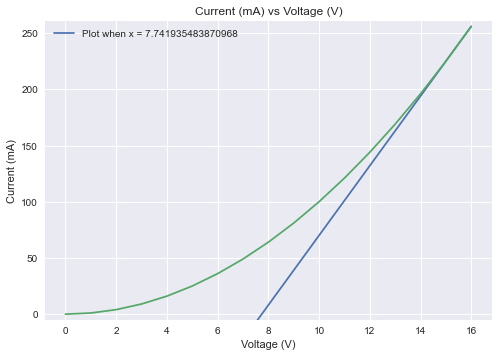

```python
one_tangent('x2_data.csv')
```

#### Two Tangents Method

```
The x value of the intersection of the two tangents is 8.0 which is the decomposition potential
```

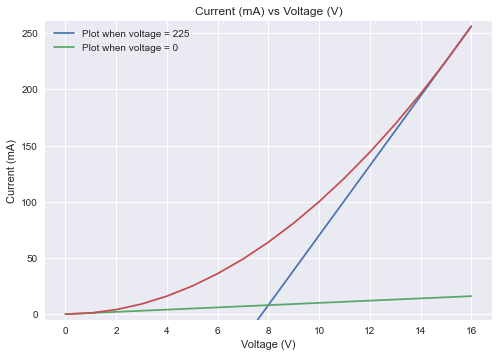

```python
two_tangents('x2_data.csv')
```

### Testing the code using a y = $e^x$ curve

#### One Tangent Method

```
The x-intercept is 14.418023293314626 which is the decomposition potential.
```

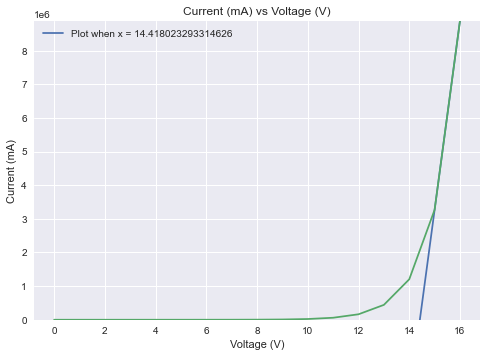

```python
one_tangent('e2_data.csv')
```

#### Two Tangents Method

```
The x value of the intersection of the two tangents is 14.418027881850835 which is the decomposition potential
```

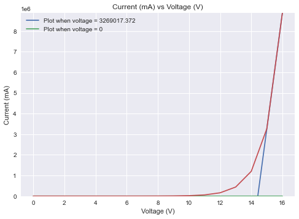

```python
two_tangents('e2_data.csv')
```

### 0.1M Sulfamic Acid

#### One Tangent Method

```
The x-intercept is 2.252083333333335 which is the decomposition potential.
```

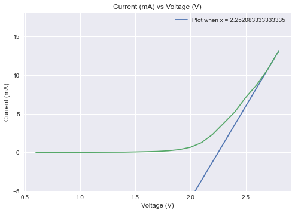

```python
one_tangent('0.1m_sulfamicacid.csv')
```

#### Two Tangents Method

```
The x value of the intersection of the two tangents is 2.254697286012528 which is the decomposition potential
```

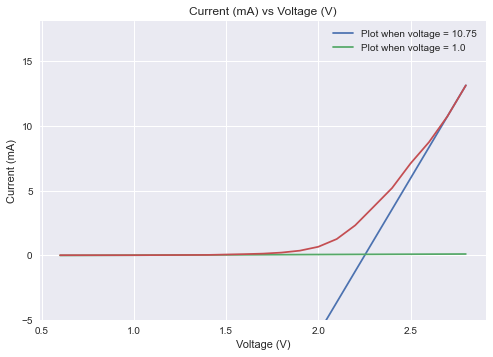

```python
two_tangents('0.1m_sulfamicacid.csv')
```

The value found by Choguill and Shell (1954) is 1.92 volts which differs from our value which is 2.25 volts.

### 0.1M Nickel Sulfamate

#### One Tangent Method

```
The x-intercept is 2.6796747967479684 which is the decomposition potential.
```

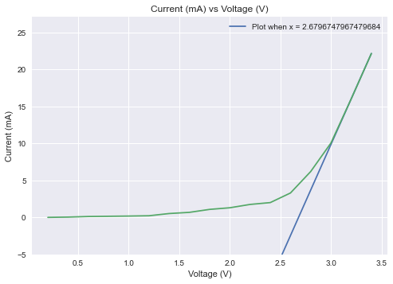

```python
one_tangent('0.1m_nisulfamate.csv')
```

The value found by Choguill and Shell (1954) is 2.15 volts which differs from our value which is 2.68 volts.

#### Two Tangents Method

```
The x value of the intersection of the two tangents is 2.695908346972178 which is the decomposition potential
```

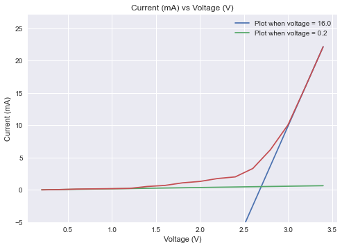

```python
two_tangents('0.1m_nisulfamate.csv')
```

The value found by Choguill and Shell (1954) is 2.17 volts which differs from our value which is 2.70 volts.

### 0.1M Copper Sulfamate

#### One Tangent Method

```
The x-intercept is 1.636363636363636 which is the decomposition potential.
```

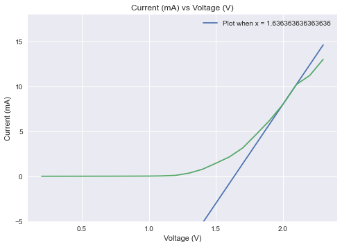

```python
one_tangent('0.1m_cusulfamate.csv')
```

The value found by Choguill and Shell (1954) is 1.44 volts which differs from our value of 1.64 volts.

#### Two Tangents Method

```
The x value of the intersection of the two tangents is 1.6374526156178917 which is the decomposition potential
```

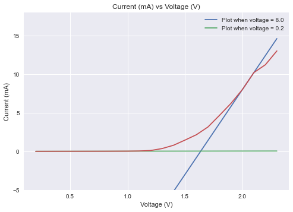

```python
two_tangents('0.1m_cusulfamate.csv')
```

The value found by Choguill and Shell (1954) is 1.45 volts which differs from our value of 1.64 volts.

#### One Tangent Method

```
The x-intercept is 2.4879432624113473 which is the decomposition potential.
```

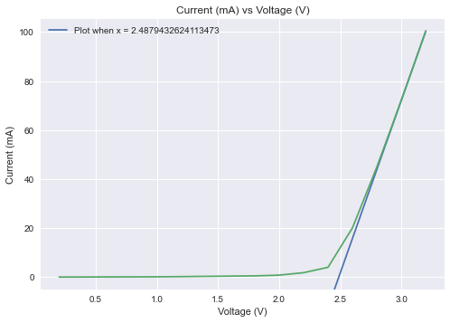

```python
one_tangent('0.1m_cdsulfamate.csv')
```

The value found by Choguill and Shell (1954) is 2.14 volts which differs from our value of 2.49 volts.

#### Two Tangents Method

```
The x value of the intersection of the two tangents is 2.4897090134847404 which is the decomposition potential
```

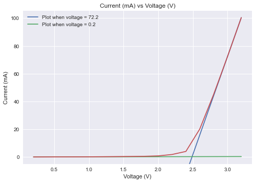

```python
two_tangents('0.1m_cdsulfamate.csv')
```

The value found by Choguill and Shell (1954) is 2.16 volts which differs from our value of 2.49 volts.

# Discussion

[figure not shown]

Figure 5: Evaluation of gradient obtained by Choguill and Shell (1954)

We have found that there is a difference between the values obtained by our code and the data from Choguill and Shell (1954).

The values that was obtained using our code was higher than the values obtained by Choguill and Shell (1954). This could be due to a improper interpretation of the data by the authors as seen in Figure 5. The tangents were likely manually drawn by the authors, resulting in some degree of inaccuracy in obtaining their decomposition potential value. The red line indicates the tangent drawn by us based on the steepest gradient while the dotted line represents the tangent drawn by the author. Therefore, there is a difference between the x-intercepts obtained by a tangent that is manually drawn tangent and a tangent done by code.

We have found that there is no difference between using the one tangent method and two tangent method to determine decompositon potential graphically. For both methods, given the same set of data, our code was able to obtain similar decoposition potential values. Hence, this shows that the decomposition values obtained using either the one tangent or two tangent method would not differ significantly.

The use of code to generate the graphs helps to provide a more standardised method of obtaining the tangents, which would be useful in providing a baseline to compare various sets of data and obtain the decompositon potential. A potential future applicaton for our code could be used to optimise industrial processes, as the importance of obtaining the decomposition potential value was discussed in an earlier section. A large risk in industrial applications is monetary losses due to product loss if there is an oversight. Hence, our code could help determine a decomposition potential value which would save time and money.

# Conclusion

In conclusion, there is a minor difference between the decomposition potential obtained using one tangent or two tangents. Thus, the difference in the values obtained by the two methods is not significant, and the choice of which method to employ could be up to preference.

# References

Cuthbertson, J.; Waddington, J. A Study Of The Cryolite–Alumina Cell With Particular Reference To Decomposition Voltage. Trans. Faraday Soc. 1936, 32, 745-760.

Choguill, H. S., & Shell, F. J. (1954). Decomposition Potentials of Some Metallic Sulfamates. Transactions of the Kansas Academy of Science (1903-), 57(3), 386. https://doi.org/10.2307/3626065

Electrolysis I https://chem.libretexts.org/Bookshelves/Analytical_Chemistry/Supplemental_Modules_(Analytical_Chemistry)/Electrochemistry/Electrolytic_Cells/Electrolysis_I (accessed Mar 31, 2022).

Ghassemi, M.; Kamvar, M.; Steinberger-Wilckens, R. Fundamentals Of Heat And Fluid Flow In High Temperature Fuel Cells. 2020.

Homann, G.; Stolz, L.; Nair, J.; Laskovic, I.; Winter, M.; Kasnatscheew, J. Poly(Ethylene Oxide)-Based Electrolyte For Solid-State-Lithium-Batteries With High Voltage Positive Electrodes: Evaluating The Role Of Electrolyte Oxidation In Rapid Cell Failure. Scientific Reports 2020, 10.

Kreka, K.; Hansen, K.; Mogensen, M.; Norrman, K.; Chatzichristodoulou, C.; Jacobsen, T. The Impact of Strong Cathodic Polarization on Ni|YSZ Microelectrodes (accessed Mar 31, 2022).

Menictas, C.; Skyllas-Kazacos, M.; Lim, T. Advances In Batteries For Medium And Large-Scale Energy Storage. 2014.

Perez, N. Kinetics Of Activation Polarization. Electrochemistry and Corrosion Science 2016, 101-150.

Sadhukhan, J. Microbial Electrosynthesis. Encyclopedia of Sustainable Technologies 2017, 455-468.

Stern, M.; Geaby, A. Electrochemical Polarization. Journal of The Electrochemical Society 1957, 104, 56.

Stuve, E. Overpotentials In Electrochemical Cells. Encyclopedia of Applied Electrochemistry 2014, 1445-1453.

Thakre, A.; Kumar, A.; Song, H.; Jeong, D.; Ryu, J. Pyroelectric Energy Conversion And Its Applications—Flexible Energy Harvesters And Sensors. Sensors 2019, 19, 2170.

Yu, J. Fundamental Principles On Nuclear Engineering; Springer: Singapore, 2022.